# Fitness Tracker Modelling Course Project

Robert Emberson

18 March 2018

## Introduction

In this project, the aim is to establish an effective predictive method for the activity dataset provided as part of the class. Essentially, the data consists of a large number of variable measurements from fitness trackers from 6 individuals, carrying out a number of repetitions of dumb-bell lifting. The participants were instructed to carry out the activities in 5 different ways - one correct form (A) and 4 other approaches that were in some specific way incorrect. From the website describing the data:

throwing the elbows to the front (Class B), lifting the dumbbell only halfway (Class C), lowering the dumbbell only halfway (Class D) and throwing the hips to the front (Class E).

First, the appropriate packages are loaded: ggplot2, reshape2, caret, rattle, and dplyr.

### Initial processing

The first step is to download and clean up the data.

```r
dir <- getwd()
url <- 'https://d396qusza40orc.cloudfront.net/predmachlearn/pml-training.csv'
download.file(url, paste(dir, '/Training_data.csv', sep = ''))
dat <- read.csv('Training_data.csv')
```

There are a large number of observations, spread across 6 participants and 10 repetitions each (according to the data description). Many of the measurements are clearly similar just from initial observation. It would be extremely computationally intensive to model the outcome based on all of the observations, so I have made two decisions:

1. Remove all variables that are incomplete (contain null values, or N/A values)
2. Take the average of the observations for the remaining 52 variables for each ‘numbered window’. This gives 858 averaged observations. Although I don’t have explicit confirmation that these represent different repetitions (since there is no data description file), it simplifies the analysis, and doesn’t impede the predictive ability. This assumption could be questioned in review, of course.

```r
set.seed(123)
dat1 <- select_if(dat, function(col){!is.factor(col) && all(is.finite(col))})
init <- dat1 %>% group_by(as.factor(num_window)) %>% summarise_all(funs(mean))
dummy <- dat %>% group_by(as.factor(num_window)) %>%
        summarise(class2 = head(classe, 1))
init <- cbind(init, dummy[,2])
```

Next, I split this ‘training’ data itself into a training and test set, so that the out-of-sample error rate can be estimated.

```r
inTrain <- createDataPartition(y = init$class2, p =0.7, list = FALSE)
training <- init[inTrain, ]
testing <- init[-inTrain, ]
```

### Model 1 - Tree

Since the outcome to be predicted is a factor, I’m first using a tree model, which should give some idea of the initial predictive ability. I show both the initially generated model, and the confusion matrix estimate for predictions on the ‘test’ partition - i.e. the out-of-sample error

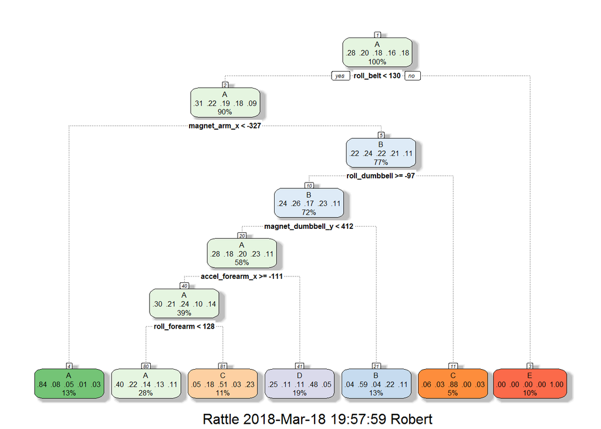

```r
variables <- training[,6:58]
mod1 <- train(class2 ~ ., data = variables, method = 'rpart')
fancyRpartPlot(mod1$finalModel)
```

```r
test_variables <- testing[,6:58]
testimates <- predict(mod1, test_variables)
confusionMatrix(testimates, test_variables$class2)$overall[1]
```

```
##  Accuracy
## 0.5215686
```

It seems like the accuracy of this model is pretty low, around 0.5. Let’s try a random forest, and a boosted decision tree, to see if this can be improved.

```r
mod2 <- train(class2 ~ ., data = variables, method = 'rf')

testimates2 <- predict(mod2, test_variables)
confusionMatrix(testimates2, test_variables$class2)
```

```
## Confusion Matrix and Statistics
##
##           Reference
## Prediction  A  B  C  D  E
##          A 69  5  3  1  0
##          B  1 42  3  0  1
##          C  2  1 38  4  3
##          D  0  1  1 35  2
##          E  0  1  0  2 40
##
## Overall Statistics
##
##                Accuracy : 0.8784
##                  95% CI : (0.8319, 0.9159)
##     No Information Rate : 0.2824
##     P-Value [Acc > NIR] : < 2.2e-16
##
##                   Kappa : 0.8459
##  Mcnemar's Test P-Value : NA
##
## Statistics by Class:
##
##                      Class: A Class: B Class: C Class: D Class: E
## Sensitivity            0.9583   0.8400   0.8444   0.8333   0.8696
## Specificity            0.9508   0.9756   0.9524   0.9812   0.9856
## Pos Pred Value         0.8846   0.8936   0.7917   0.8974   0.9302
## Neg Pred Value         0.9831   0.9615   0.9662   0.9676   0.9717
## Prevalence             0.2824   0.1961   0.1765   0.1647   0.1804
## Detection Rate         0.2706   0.1647   0.1490   0.1373   0.1569
## Detection Prevalence   0.3059   0.1843   0.1882   0.1529   0.1686
## Balanced Accuracy      0.9546   0.9078   0.8984   0.9073   0.9276
```

So this is much better - accuracy rate of 0.87. Can we do any better with a relatively simple model? Let’s try a boosted tree model.

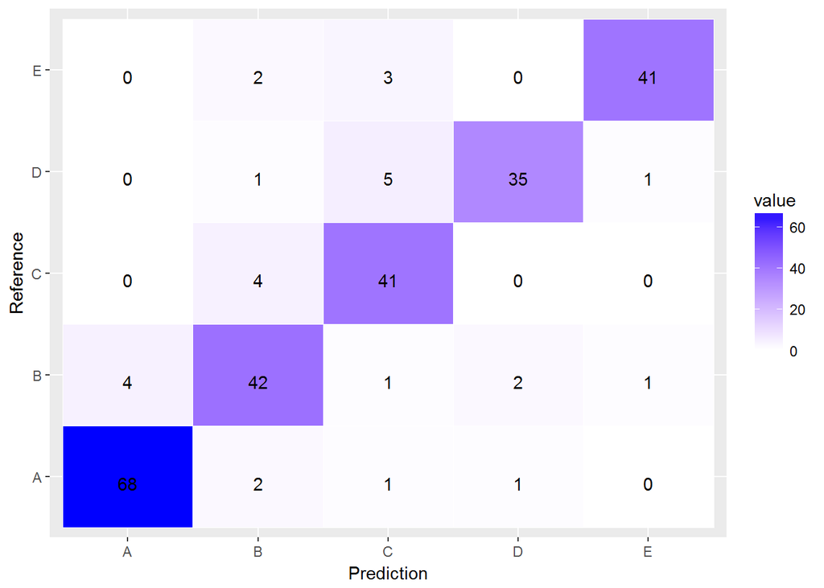

```r
irrel <- capture.output(mod3 <- train(class2 ~ ., data = variables, method = 'gbm'))

testimates3 <- predict(mod3, test_variables)
a <- confusionMatrix(testimates3, test_variables$class2)
aa <- melt(a$table)
ggplot(data = aa, aes(x=Prediction, y=Reference, fill=value)) +
        geom_tile(aes(fill = value), colour = "white") +
        scale_fill_gradient(low = 'white', high = 'blue') +
        geom_text(aes(label = sprintf("%1.0f", value)), vjust = 1)
```

```r
a$overall[1]
```

```
##  Accuracy
## 0.8901961
```

So this third model offers a reasonable out-of-sample error rate (~0.89), and is not very computationally expensive. Thus, I’m prepared to choose this as the final model.